# 8 Buffer-Based Access

## 8.1 Overview

In Part 1, we created buffers around methadone clinics in Chicago to visualize areas within one and two miles of a provider. These maps helped us explore the geographic distribution of resources and their surrounding areas. We can now build on that analysis by calculating measures that allow us to compare resource availability and coverage across communities.

Resource counts describe how many clinics are located within an area. **Resource density** expresses that count relative to the area’s size, measured here as clinics per square mile. **Buffer-based coverage** describes area-based proximity: how much of an area lies within a specified distance of at least one clinic. These measures capture different aspects of resource availability. An area with no clinics inside its boundaries may still be partially covered by a buffer around a nearby clinic. None of these measures directly incorporates population demand.

In this tutorial, we use the same Chicago methadone clinic locations and ZIP Code area boundaries introduced in Part 1. We will calculate clinic counts and density for each ZIP Code area, then use provider buffers to calculate the percentage of each area’s surface covered within one and two miles of a clinic. Comparing these distances will help us understand how the choice of buffer radius affects our results. These coverage measures describe area-based proximity using straight-line distance. They do not represent the percentage of residents served or actual travel times.

Our objectives are thus to:

- Count methadone clinics within each ZIP Code area
- Calculate resource density as the number of clinics per square mile
- Calculate the percentage of each area covered by provider buffers
- Compare coverage using one-mile and two-mile buffers
- Map and save the resulting area-level measures

## 8.2 Environment Setup

To replicate the code and functions illustrated in this tutorial, you’ll need to have R and RStudio downloaded and installed on your system. This tutorial assumes some familiarity with the R programming language and the buffer operations introduced in the Buffer Analysis chapter.

### 8.2.1 Input/Output

Our inputs will be the same methadone clinic locations and Chicago ZIP Code area boundaries used in Part 1.

- Chicago Methadone Clinics: `methadone_clinics.shp`
- Chicago ZIP Code Areas: `chicago_zips.shp`

We will use these datasets to count clinics within each area, calculate resource density, and measure the percentage of each area covered by one-mile and two-mile provider buffers. We will recreate the buffers in this tutorial, so a previously saved buffer file is not required.

Our final outputs will include a CSV file and a shapefile containing three types of measures for each ZIP Code area:

- **Resource Count**: the number of methadone clinics within the area
- **Resource Density**: the number of clinics per square mile
- **Buffer Coverage**: the percentage of the area within one mile and two miles of at least one clinic

The outputs will also retain each area’s size in square miles, used to calculate density and coverage, and the difference between one-mile and two-mile coverage in percentage points.

These outputs can be used for mapping, comparison across areas, or further spatial analysis.

### 8.2.2 Load Libraries

We will use the following packages in this tutorial:

- `sf`: to manipulate spatial data and perform spatial operations
- `dplyr`: to manipulate and summarize data
- `tmap`: to visualize and create maps
- `units`: to convert distance and area units

First, load the required libraries.

```r
library(sf)
library(dplyr)
library(tmap)
library(units)
```

## 8.3 Load and Prepare Data

First, load the methadone clinic locations and Chicago ZIP Code area boundaries used in Part 1.

```r
metClinics <- st_read("data/methadone_clinics.shp")
areas <- st_read("data/chicago_zips.shp")
```

Let’s take a look at the first few rows of each dataset.

```r
head(metClinics)
```

```
Simple feature collection with 6 features and 8 fields
Geometry type: POINT
Dimension:     XY
Bounding box:  xmin: -87.67818 ymin: 41.89268 xmax: -87.63409 ymax: 41.96475
Geodetic CRS:  WGS 84
  X                                                         Name
1 1                Chicago Treatment and Counseling Center, Inc.
2 2                      Sundace Methadone Treatment Center, LLC
3 3 Soft Landing Interventions/DBA Symetria Recovery of Lakeview
4 4                                        PDSSC - Chicago, Inc.
5 5                          Center for Addictive Problems, Inc.
6 6                                Family Guidance Centers, Inc.
                  Address    City State   Zip
1 4453 North Broadway st. Chicago    IL 60640
2 4545 North Broadway St. Chicago    IL 60640
```

[output cut: 18 more lines]

```r
head(areas)
```

```
Simple feature collection with 6 features and 4 fields
Geometry type: MULTIPOLYGON
Dimension:     XY
Bounding box:  xmin: -87.80649 ymin: 41.88747 xmax: -87.59852 ymax: 41.93228
Geodetic CRS:  WGS84(DD)
  objectid shape_area shape_len   zip                       geometry
1       33  106052287  42720.04 60647 MULTIPOLYGON (((-87.67762 4...
2       34  127476051  48103.78 60639 MULTIPOLYGON (((-87.72683 4...
3       35   45069038  27288.61 60707 MULTIPOLYGON (((-87.785 41....
4       36   70853834  42527.99 60622 MULTIPOLYGON (((-87.66707 4...
5       37   99039621  47970.14 60651 MULTIPOLYGON (((-87.70656 4...
6       38   23506056  34689.35 60611 MULTIPOLYGON (((-87.61401 4...
```

The clinic dataset contains point locations, while the area dataset contains Chicago ZIP Code area boundaries. The `zip` field identifies each area and will be retained alongside the measures calculated in this tutorial.

Next, transform both datasets to the same projected coordinate reference system (CRS) for area and buffer calculations. As in Part 1, we will use NAD83 / Illinois East (ftUS), with an EPSG code of 3435. We first define the target CRS, then apply it to both datasets using `st_transform()`.

**TipCheck your CRS and units**

Matching coordinate systems is only part of the check—coordinate units also matter. For this workflow, use a projected CRS with linear units, such as feet or meters, rather than latitude and longitude in degrees.

EPSG: 3435 uses US survey feet, so a buffer distance entered as a plain number would be interpreted in feet, not miles. We will use `units` to specify buffer distances in miles explicitly and convert area measurements to square miles.

```r
CRS.new <- st_crs(3435)

metClinics.3435 <- st_transform(metClinics, CRS.new)
areas.3435 <- st_transform(areas, CRS.new)
```

Check that the coordinate reference systems match before proceeding.

```r
st_crs(metClinics.3435) == st_crs(areas.3435)
```

```
[1] TRUE
```

The result should be `TRUE`. We can now use these projected datasets to count resources, calculate areas, and create provider buffers. When reporting our results, we will convert area measurements to square miles.

Our calculations will describe access to the clinics included in the input dataset. Clinics outside the dataset will not contribute to the counts or buffer coverage, which should be considered when interpreting results near the study area’s boundary.

## 8.4 Calculate Resource Counts and Density

Resource counts provide a simple starting point for comparing the distribution of methadone clinics across areas. However, ZIP Code areas vary in size. We can account for these differences by calculating resource density, expressed as the number of clinics per square mile.

### 8.4.1 Count Resources Within Areas

First, identify the clinics that intersect each ZIP Code area using `st_intersects()`. This function returns a list containing the indices of the clinic points associated with each area. We can use `lengths()` to count the number of matches.

```r
clinicMatches <- st_intersects(areas.3435, metClinics.3435)

areas.3435$clinic_n <- lengths(clinicMatches)
```

Inspect the counts alongside the ZIP Code identifiers.

```r
areas.3435 %>%
  st_drop_geometry() %>%
  select(zip, clinic_n) %>%
  head()
```

```
    zip clinic_n
1 60647        0
2 60639        0
3 60707        0
4 60622        0
5 60651        1
6 60611        0
```

The `clinic_n` field contains the number of clinic points intersecting each area. Areas with no matching clinics receive a count of zero.

This approach includes points on polygon boundaries. A clinic located exactly on a shared boundary may be counted in both adjacent areas, so boundary matches should be checked if each clinic must be assigned to only one area.

### 8.4.2 Calculate Resource Density

Next, calculate the size of each ZIP Code area using `st_area()`. Because our projected CRS uses US survey feet, we will convert the resulting area measurements to square miles with `set_units()`.

```r
areaSqMi <- set_units(st_area(areas.3435), "mi^2")

areas.3435$area_sqmi <- as.numeric(areaSqMi)
```

We store the area measurements as numeric values for calculation and export. The field name `area_sqmi` indicates that the values are in square miles. These measurements use the polygon geometries as provided, but they do not separately exclude water areas.

We can now divide each area’s clinic count by its area to calculate resource density.

```r
areas.3435 <- areas.3435 %>%
  mutate(dens_sqmi = clinic_n / area_sqmi)
```

Inspect the resulting measures.

```r
areas.3435 %>%
  st_drop_geometry() %>%
  select(zip, clinic_n, area_sqmi, dens_sqmi) %>%
  head()
```

```
    zip clinic_n area_sqmi dens_sqmi
1 60647        0 3.8041176 0.0000000
2 60639        0 4.5725924 0.0000000
3 60707        0 1.6166358 0.0000000
4 60622        0 2.5415418 0.0000000
5 60651        1 3.5525718 0.2814862
6 60611        0 0.8431671 0.0000000
```

The `dens_sqmi` field represents the number of clinics per square mile. For example, an area containing two clinics across four square miles would have a density of 0.5 clinics per square mile. If two areas contain the same number of clinics, the smaller area will have a higher resource density.

Counts and density describe resources within area boundaries. They do not account for nearby clinics outside those boundaries or the distribution of residents within each area. In the next section, we will use provider buffers to measure how much of each area lies within a specified distance of at least one clinic.

## 8.5 Calculate Buffer-Based Coverage

Resource counts and density describe clinics within area boundaries. Buffer-based coverage provides a different perspective: the percentage of each area located within a specified distance of at least one clinic. This allows nearby clinics to contribute to an area’s coverage even when they are located outside its boundaries.

### 8.5.1 Prepare Provider Buffers

As in Part 1, we will create one-mile and two-mile buffers around the methadone clinic locations. We use `set_units()` to specify the distances in miles so that `st_buffer()` can convert them to the units of our projected CRS.

```r
clinicBuffers1mi <- st_buffer(
  metClinics.3435,
  dist = set_units(1, "mi")
)

clinicBuffers2mi <- st_buffer(
  metClinics.3435,
  dist = set_units(2, "mi")
)
```

Before combining the buffers, let’s visually inspect them alongside the clinic locations and ZIP Code boundaries.

First, plot the one-mile buffers. The blue outlines show the buffers, and the red points show the clinics.

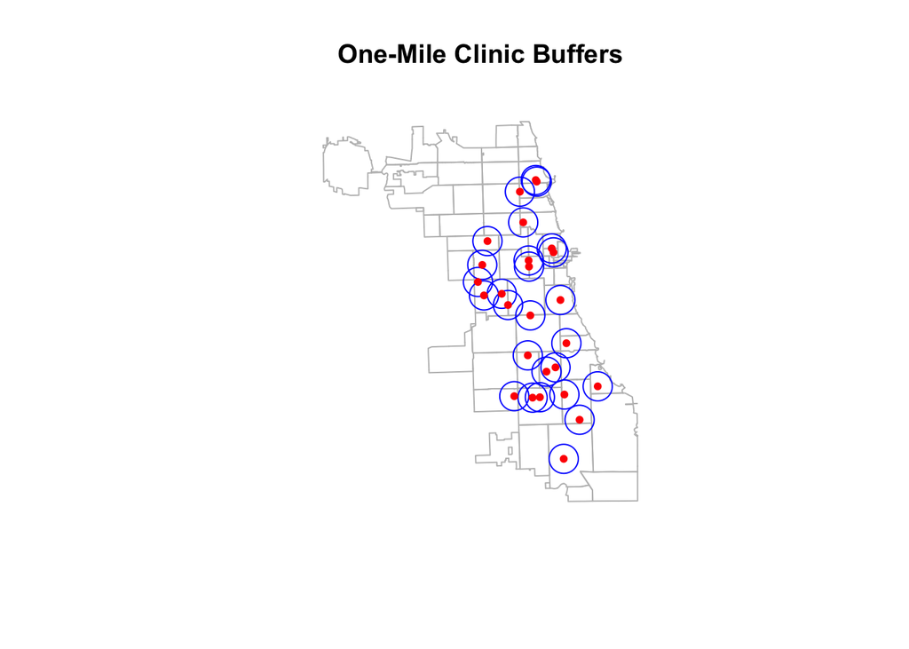

```r
plot(
  st_geometry(areas.3435),
  border = "grey",
  main = "One-Mile Clinic Buffers"
)
plot(
  st_geometry(clinicBuffers1mi),
  add = TRUE,
  border = "blue"
)
plot(
  st_geometry(metClinics.3435),
  add = TRUE,
  col = "red",
  pch = 20
)
```

Next, plot the two-mile buffers using the same ZIP Code boundaries as the map extent.

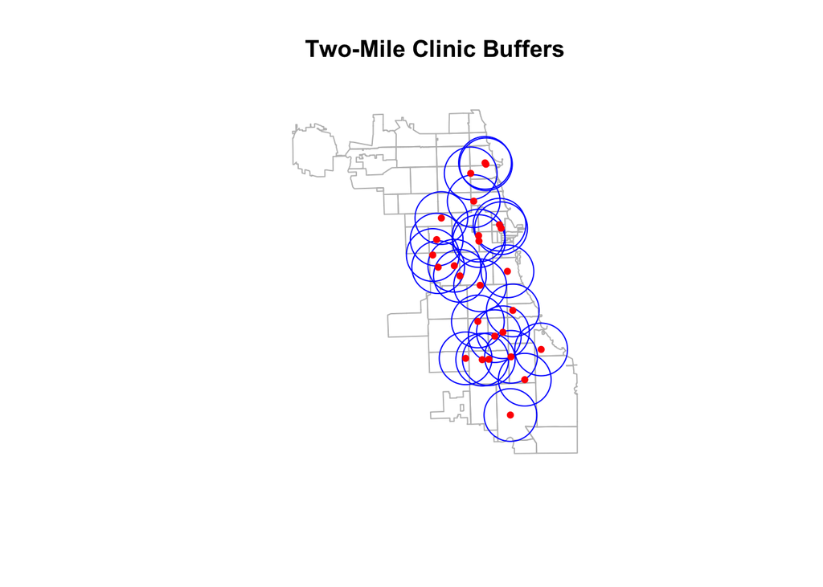

```r
plot(
  st_geometry(areas.3435),
  border = "grey",
  main = "Two-Mile Clinic Buffers"
)
plot(
  st_geometry(clinicBuffers2mi),
  add = TRUE,
  border = "blue"
)
plot(
  st_geometry(metClinics.3435),
  add = TRUE,
  col = "red",
  pch = 20
)
```

Each buffer should be centered on a clinic, and the two-mile buffers should extend farther than the one-mile buffers. Overlapping buffers and buffers extending across ZIP Code boundaries are expected. If the buffers appear unusually small or large, or do not align with the clinic locations, check the CRS and distance units before proceeding.

Next, combine the buffers for each distance using `st_union()`. This ensures that locations covered by multiple clinic buffers are counted only once when calculating coverage.

```r
unionBuffers1mi <- st_union(clinicBuffers1mi)
unionBuffers2mi <- st_union(clinicBuffers2mi)
```

The resulting geometries represent the combined areas within one and two miles of at least one clinic. For a more detailed introduction to creating and combining buffers, see the Buffer Analysis chapter.

### 8.5.2 Calculate Coverage by Area

We will calculate coverage by intersecting each ZIP Code area with the combined provider buffers, measuring the intersecting area, and dividing it by the original area’s total size.

Let’s first work through this calculation for a single ZIP Code area using the one-mile buffers.

**Calculate coverage for one area**

Select the first ZIP Code area. The `[1, ]` selects the first row while retaining all columns, including its geometry.

```r
exampleArea <- areas.3435[1, ]
```

Use `st_intersection()` to find the portion of this area that overlaps the combined one-mile buffers. We use `st_geometry()` because this step only needs the area’s shape.

```r
exampleOverlap <- st_intersection(
  st_geometry(exampleArea),
  unionBuffers1mi
)
```

Next, measure the overlapping area with `st_area()` and sum the resulting areas. Convert the total to square miles so that it matches the units of `area_sqmi`.

```r
exampleCoveredArea <- sum(st_area(exampleOverlap))

exampleCoveredSqMi <- as.numeric(
  set_units(exampleCoveredArea, "mi^2")
)
```

Divide the covered area by the ZIP Code area’s total size and multiply by 100 to calculate coverage as a percentage.

```r
exampleCoveragePct <- exampleCoveredSqMi / exampleArea$area_sqmi * 100

data.frame(
  zip = exampleArea$zip,
  cov1mi_pct = exampleCoveragePct
)
```

```
    zip cov1mi_pct
1 60647   41.88014
```

The result tells us what percentage of this ZIP Code area lies within one mile of at least one clinic in our dataset. Because we combined the provider buffers before calculating the intersection, locations near multiple clinics are counted only once.

**Repeat the calculation with a function**

We need to repeat these steps for every ZIP Code area and for both buffer distances. Rather than writing the same calculation each time, we can place the steps in a helper function called `calculateCoveredArea()`.

The function takes two inputs: `areaData`, containing the area boundaries, and `bufferUnion`, containing the combined provider buffers. It returns the covered area in square miles for each ZIP Code area.

```r
calculateCoveredArea <- function(areaData, bufferUnion) {
  vapply(seq_len(nrow(areaData)), function(i) {
    overlap <- st_intersection(
      st_geometry(areaData)[i],
      bufferUnion
    )

    coveredArea <- sum(st_area(overlap))

    as.numeric(set_units(coveredArea, "mi^2"))
  }, numeric(1))
}
```

Inside the function, `seq_len(nrow(areaData))` supplies the row numbers, and `vapply()` repeats the calculation for each row. The index `i` selects the current area’s geometry, replacing the single area we selected in our example. The final `numeric(1)` specifies that each calculation should return one numeric value. Areas with no overlap receive a covered area of zero.

Apply the function to the one-mile and two-mile buffers. The returned values follow the same row order as `areas.3435`.

```r
covered1mi <- calculateCoveredArea(areas.3435, unionBuffers1mi)
covered2mi <- calculateCoveredArea(areas.3435, unionBuffers2mi)
```

As in our single-area example, divide the covered areas by the total area measurements and multiply by 100 to obtain percentages.

```r
areas.3435 <- areas.3435 %>%
  mutate(
    cov1mi_pct = covered1mi / area_sqmi * 100,
    cov2mi_pct = covered2mi / area_sqmi * 100
  )
```

Inspect the coverage measures. The one-mile coverage for the first row should match the result from our single-area example.

```r
areas.3435 %>%
  st_drop_geometry() %>%
  select(zip, cov1mi_pct, cov2mi_pct) %>%
  head()
```

```
    zip cov1mi_pct cov2mi_pct
1 60647  41.880135  100.00000
2 60639   5.954412   43.42224
3 60707   0.000000    0.00000
4 60622  34.525175  100.00000
5 60651  48.677593   78.53439
6 60611  71.064406  100.00000
```

A value of 0 indicates that none of the area’s surface falls within the specified distance of a clinic in our dataset. An area may have zero coverage if it lies outside all provider buffers at the selected distance. This result applies only to the clinics included in our dataset; nearby clinics not represented in the data will not contribute to coverage.

A value of 100 indicates complete area coverage. For example, a one-mile coverage value of 50 means that half of the area’s surface lies within one mile of at least one clinic.

These percentages describe area coverage, not population coverage. They do not indicate the percentage of residents living within the buffers or receiving treatment.

### 8.5.3 Compare Buffer Distances

The two-mile buffers cover at least as much area as the one-mile buffers. We can compare the two coverage percentages to measure how much additional area is covered when we increase the buffer radius.

For each ZIP Code area, we calculate:

$$\text{Coverage change (percentage points)}
=
\text{Two-mile coverage (\%)}
-
\text{One-mile coverage (\%)}$$

Both coverage percentages use the same ZIP Code area as their denominator. The difference therefore represents the additional share of that area’s surface covered by the larger buffers. For example, if coverage increases from 20% to 65%, the additional coverage is 45 percentage points.

This comparison provides a simple sensitivity analysis: it shows how our coverage results change when we change the distance threshold from one mile to two miles.

```r
areas.3435 <- areas.3435 %>%
  mutate(covDiff_pp = cov2mi_pct - cov1mi_pct)
```

The `covDiff_pp` field stores this coverage change in percentage points.

We can sort the results from largest to smallest change using `arrange(desc())`. The code below displays the six areas with the largest increases in coverage.

```r
areas.3435 %>%
  st_drop_geometry() %>%
  select(zip, cov1mi_pct, cov2mi_pct, covDiff_pp) %>%
  arrange(desc(covDiff_pp)) %>%
  head()
```

```
    zip  cov1mi_pct cov2mi_pct covDiff_pp
1 60605  0.03000426  100.00000   99.97000
2 60604 15.39568042  100.00000   84.60432
3 60653 20.73528657  100.00000   79.26471
4 60637 29.00737801   97.85600   68.84863
5 60657 26.69424803   94.38692   67.69268
6 60622 34.52517458  100.00000   65.47483
```

A large increase indicates that a substantial share of the area falls outside the one-mile buffers but inside the two-mile buffers. Its coverage result is therefore sensitive to the distance threshold within the range examined.

A small increase should be interpreted alongside the original coverage values. An area may already have high coverage at one mile, leaving little additional area to cover. Alternatively, it may remain poorly covered even at two miles.

Because the two-mile buffers contain the one-mile buffers, the coverage change should be nonnegative, allowing for minor numerical rounding differences. The clinic counts and resource density remain unchanged because the clinic locations and ZIP Code boundaries have not changed.

Increasing the buffer radius changes our definition of proximity; it does not represent an improvement in actual services. Both buffer distances describe straight-line proximity rather than travel distances or travel times.

## 8.6 Visualize & Interpret Results

We can now map the resource density and buffer coverage measures calculated in the previous sections. These maps describe different aspects of resource availability: density summarizes clinics within each area relative to its size, while coverage describes the proportion of an area located near at least one clinic.

First, switch to the static plotting mode.

```r
tmap_mode("plot")
```

### 8.6.1 Map Resource Density

We will map the number of clinics per square mile and overlay the clinic locations. Areas with a value of zero have no clinics counted within their boundaries.

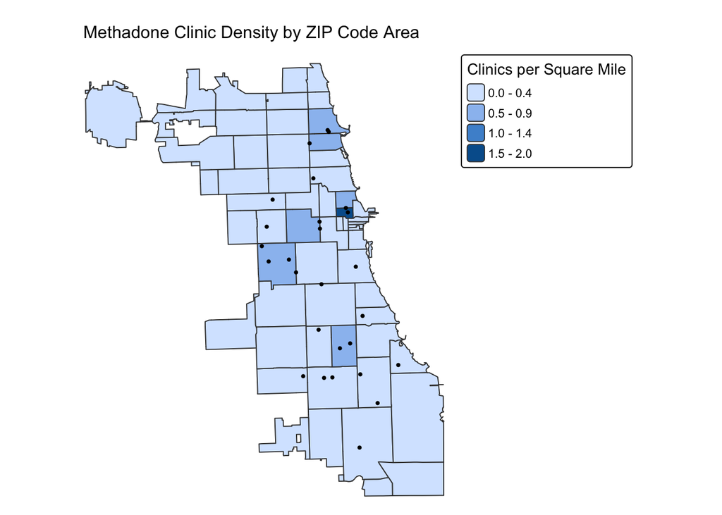

```r
tm_shape(areas.3435) +
  tm_polygons(
    fill = "dens_sqmi",
    fill.scale = tm_scale_intervals(style = "pretty", n = 5),
    fill.legend = tm_legend(title = "Clinics per Square Mile")
  ) +
  tm_shape(metClinics.3435) +
  tm_dots(size = 0.2) +
  tm_title(
    "Methadone Clinic Density by ZIP Code Area",
    position = tm_pos_out("center", "top"),
    size = 1
  ) +
  tm_layout(frame = FALSE)
```

Higher density values indicate more clinics relative to the size of an area. They do not necessarily indicate that clinics are evenly distributed within the area or that they have sufficient capacity to serve the surrounding population.

### 8.6.2 Compare Coverage Maps

Next, map the percentage of each area covered by the one-mile and two-mile provider buffers.

For these maps, we will use the same percentage breaks and color palette. This ensures that the same color represents the same coverage range in both maps.

```r
coverageBreaks <- c(0, 20, 40, 60, 80, 100)

coverageColors <- c(
  "#eff3ff",
  "#bdd7e7",
  "#6baed6",
  "#3182bd",
  "#08519c"
)
```

First, map one-mile coverage.

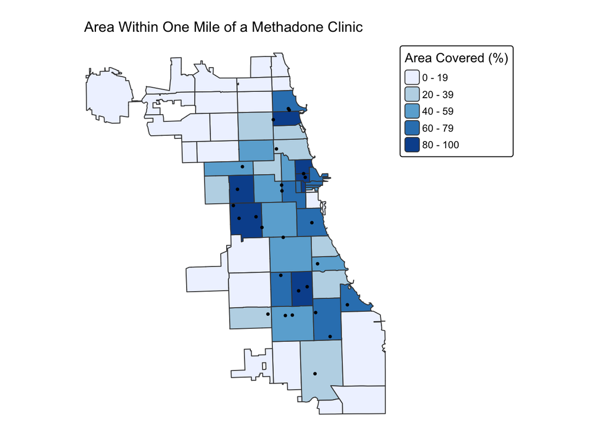

```r
tm_shape(areas.3435) +
  tm_polygons(
    fill = "cov1mi_pct",
    fill.scale = tm_scale_intervals(
      breaks = coverageBreaks,
      values = coverageColors
    ),
    fill.legend = tm_legend(title = "Area Covered (%)")
  ) +
  tm_shape(metClinics.3435) +
  tm_dots(size = 0.2) +
  tm_title(
    "Area Within One Mile of a Methadone Clinic",
    position = tm_pos_out("center", "top"),
    size = 1
  ) +
  tm_layout(frame = FALSE)
```

Then, map two-mile coverage using the same scale.

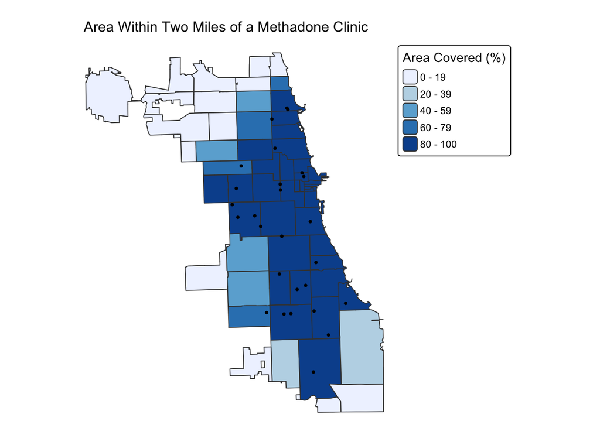

```r
tm_shape(areas.3435) +
  tm_polygons(
    fill = "cov2mi_pct",
    fill.scale = tm_scale_intervals(
      breaks = coverageBreaks,
      values = coverageColors
    ),
    fill.legend = tm_legend(title = "Area Covered (%)")
  ) +
  tm_shape(metClinics.3435) +
  tm_dots(size = 0.2) +
  tm_title(
    "Area Within Two Miles of a Methadone Clinic",
    position = tm_pos_out("center", "top"),
    size = 1
  ) +
  tm_layout(frame = FALSE)
```

Darker shades indicate greater area coverage. Compare the two maps to identify areas where coverage increases substantially and areas that remain poorly covered at both distances. The `covDiff_pp` field calculated earlier provides the exact change in percentage points for each area.

### 8.6.3 Interpret the Results

Consider the following questions when comparing the maps:

- Which areas have few or no clinics within their boundaries?
- Do any areas with no clinics still have coverage from nearby providers outside their boundaries?
- Which areas show the largest increase in coverage between one and two miles?
- Which areas remain poorly covered at both distances?

Counts, density, and coverage should be interpreted together. Density describes the number of clinics relative to area size, while coverage describes how much of an area is near at least one clinic. An area may have a high clinic density but incomplete coverage if its clinics are concentrated in one location. Conversely, an area with no clinics inside its boundaries may still be close to clinics in neighboring areas.

These calculations use clinic locations and area boundaries, without incorporating population demand. For example, two areas with the same clinic density and buffer coverage could have very different numbers of residents who may need services. Similar values therefore do not necessarily indicate that resources are equally adequate for the populations they serve.

The measures also do not account for treatment capacity, transportation barriers, or whether residents can use a particular clinic. In the Advanced Access Metrics chapter, we will introduce approaches that combine resource supply, population-based demand, and travel time.

## 8.7 Save Data

We can now save the resource counts, density, and buffer coverage measures for future mapping and analysis.

First, select the ZIP Code identifier and the measures calculated in this tutorial. The spatial geometry will be retained automatically when selecting columns from an `sf` object.

```r
bufferAccessSf <- areas.3435 %>%
  select(
    zip,
    clinic_n,
    area_sqmi,
    dens_sqmi,
    cov1mi_pct,
    cov2mi_pct,
    covDiff_pp
  )

head(bufferAccessSf)
```

```
Simple feature collection with 6 features and 7 fields
Geometry type: MULTIPOLYGON
Dimension:     XY
Bounding box:  xmin: 1127607 ymin: 1902374 xmax: 1184320 ymax: 1918596
Projected CRS: NAD83 / Illinois East (ftUS)
    zip clinic_n area_sqmi dens_sqmi cov1mi_pct cov2mi_pct covDiff_pp
1 60647        0 3.8041176 0.0000000  41.880135  100.00000   58.11986
2 60639        0 4.5725924 0.0000000   5.954412   43.42224   37.46783
3 60707        0 1.6166358 0.0000000   0.000000    0.00000    0.00000
4 60622        0 2.5415418 0.0000000  34.525175  100.00000   65.47483
5 60651        1 3.5525718 0.2814862  48.677593   78.53439   29.85680
6 60611        0 0.8431671 0.0000000  71.064406  100.00000   28.93559
                        geometry
1 MULTIPOLYGON (((1162711 191...
2 MULTIPOLYGON (((1149304 191...
3 MULTIPOLYGON (((1133505 190...
4 MULTIPOLYGON (((1165664 190...
5 MULTIPOLYGON (((1154895 190...
6 MULTIPOLYGON (((1180097 190...
```

The output includes the following fields:

- `zip`: ZIP Code area identifier
- `clinic_n`: number of clinics intersecting the area
- `area_sqmi`: area size in square miles
- `dens_sqmi`: number of clinics per square mile
- `cov1mi_pct`: percentage of the area within one mile of at least one clinic
- `cov2mi_pct`: percentage of the area within two miles of at least one clinic
- `covDiff_pp`: increase in coverage from one mile to two miles, in percentage points

To save the results as a CSV file, use `st_drop_geometry()` to remove the spatial geometry. Setting `row.names = FALSE` avoids adding an extra row-number column.

```r
write.csv(
  st_drop_geometry(bufferAccessSf),
  "data/chizips_BufferAccess.csv",
  row.names = FALSE
)
```

We can also save the results as a shapefile, retaining the area boundaries for future mapping and spatial analysis.

```r
write_sf(
  bufferAccessSf,
  "data/chizips_BufferAccess.shp"
)
```

Both outputs contain the same area-level measures. The CSV can be used for tabular analysis or linked to compatible area data using the ZIP Code identifier, while the shapefile includes the geometries needed for mapping.